# Housefly wing lengths

Bhavik Kollipara

10/13/2021

## The data

What does the distribution of housefly wing lengths (in mm) look like? This was apparently an important question in 1955, and the data set we look at is a famous one, from Sokal & Hunter, reproduced here:

https://seattlecentral.edu/qelp/sets/057/057.html

The data set can be scanned in from the web:

```r
wing.length <- scan("https://seattlecentral.edu/qelp/sets/057/s057.txt")
```

This reads the data in as a vector. To use `ggplot()`, we need the data in a data frame. The following code creates a data frame called `wings.df` that contains a variable called `Length`:

```r
wings.df <- data.frame(Length = wing.length)
```

We also need to load the `ggplot2` package to use the functions in it:

```r
library(ggplot2)
```

## Summary statistics

Find the sample mean:

```r
mean(wings.df$Length)
```

```
## [1] 45.5
```

The sample mean fly wing length is 45.5 millimeters.

Find the plug-in standard deviation and the sample standard deviation:

```r
# Plug-in
sqrt(mean(wings.df$Length^2) - mean(wings.df$Length)^2)
```

```
## [1] 3.9
```

```r
# Sample SD
sd(wings.df$Length)
```

```
## [1] 3.919647
```

There’s hardly any difference. To one decimal place, the standard deviation of fly wing lengths is 3.9 millimeters.

We can also describe the data using the five-number summary:

```r
summary(wings.df)
```

```
##      Length
##  Min.   :36.0
##  1st Qu.:43.0
##  Median :45.5
##  Mean   :45.5
##  3rd Qu.:48.0
##  Max.   :55.0
```

The median fly wing length is 45.5 millimeters. The interquartile range is 5.0 millimeters.

## Plot the data

Plot the empirical CDF:

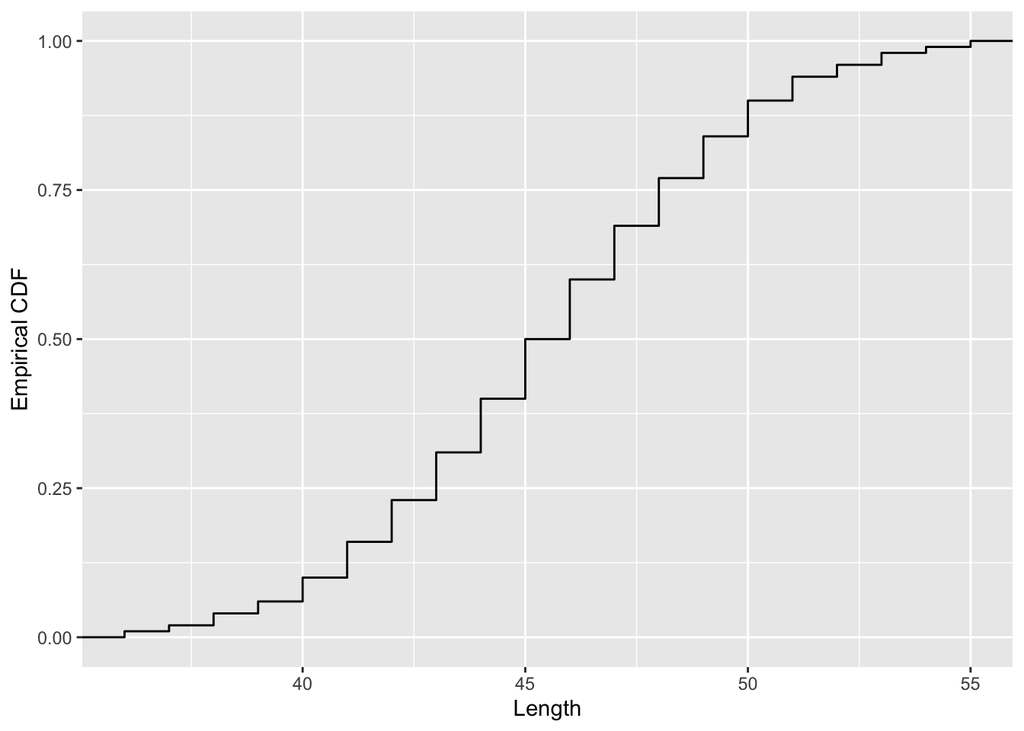

```r
ggplot(wings.df, aes(x = Length)) + stat_ecdf() + ylab("Empirical CDF")
```

Draw a histogram:

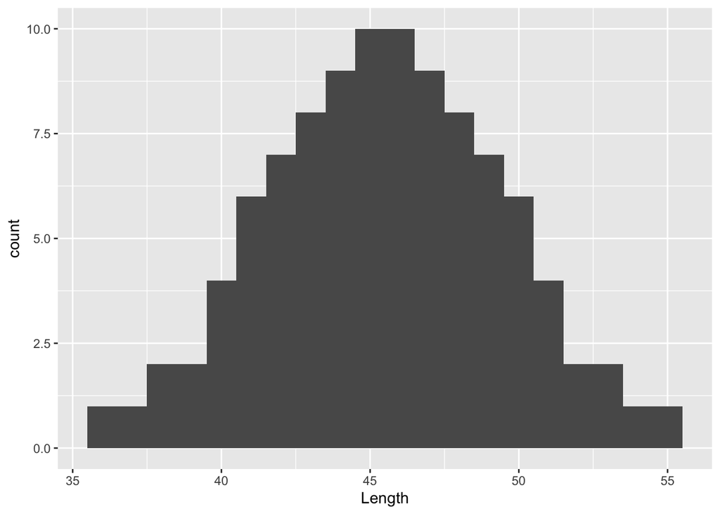

```r
ggplot(wings.df, aes(x = Length)) + geom_histogram(breaks = seq(35.5, 55.5, 1))
```

Draw a density estimate:

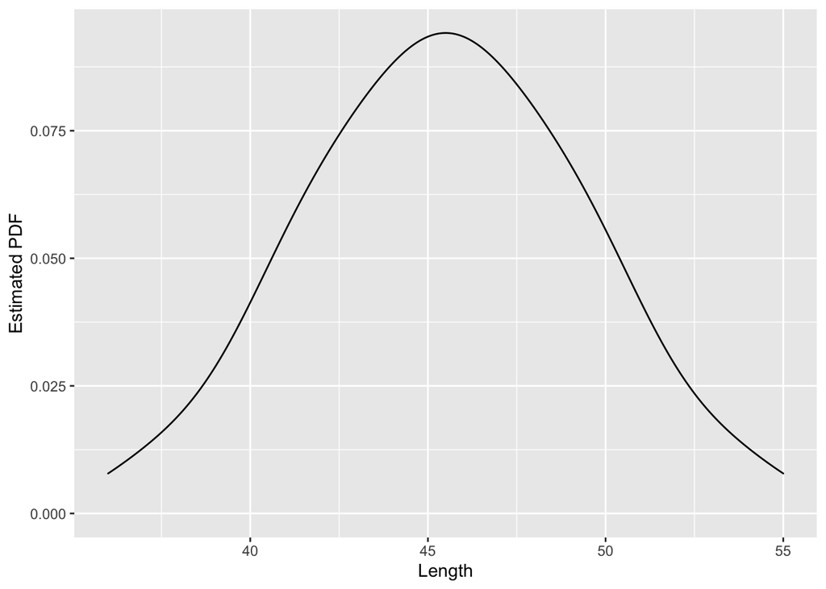

```r
ggplot(wings.df, aes(x = Length)) + geom_density() + ylab("Estimated PDF")
```

Draw a normal quantile-quantile plot:

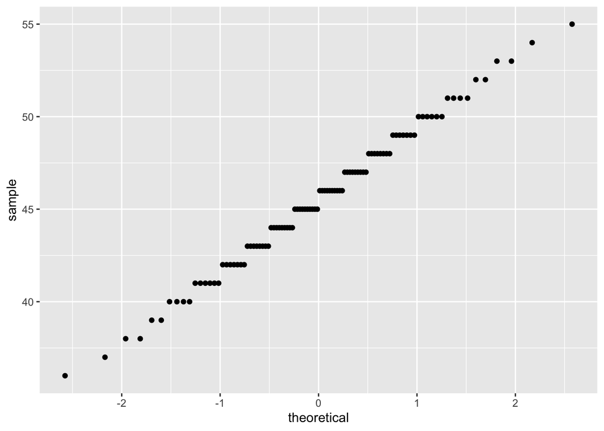

```r
ggplot(wings.df, aes(sample = Length)) + stat_qq()
```

There’s one thing about the data that might make one suspicious that the data is made up. The suspicious thing is: the data is concentrated at certain intervals.